# Notebook 2 — Analyse : ACP, Clustering et Visualisations

## Projet : Étude de marché internationale — La Poule qui Chante

**Point d'entrée :** `donnees_fao__clean.csv` (produit par le Notebook 1)

**Ce notebook couvre :**

- Chargement et normalisation des données
- Analyse en Composantes Principales (ACP)
- Classification Ascendante Hiérarchique (CAH)
- K-means
- Visualisations et recommandations

## 0. Imports et configuration

```python
import pandas as pd
import numpy as np
import matplotlib.pyplot as plt
import seaborn as sns
import warnings
import os

from sklearn.preprocessing import StandardScaler

warnings.filterwarnings('ignore')
plt.rcParams['figure.figsize'] = (12, 5)
plt.rcParams['axes.titlesize'] = 13
plt.rcParams['axes.labelsize'] = 11
sns.set_style('whitegrid')

os.makedirs('outputs', exist_ok=True)

print(' Imports OK')
```

```
 Imports OK
```

## 1. Chargement et normalisation des données

### 1.1 Chargement

```python
# Chargement du fichier produit par le Notebook 1
df = pd.read_csv('D:/dataAnalyst/Projet11/travail/donnees_fao__clean.csv', encoding='utf-8')

print(f'Dataset chargé : {df.shape[0]} pays × {df.shape[1]} colonnes')
print(f'Valeurs manquantes : {df.isnull().sum().sum()}')
print()
df.head(10)
```

```
Dataset chargé : 96 pays × 11 colonnes
Valeurs manquantes : 0
```

|  | pays | region | population_M | pib_hab_usd | volaille_kg_hab | proteines_g | stabilite_politique | import_volaille_t | taux_urbanisation | controle_corruption | annee |
| --- | --- | --- | --- | --- | --- | --- | --- | --- | --- | --- | --- |
| 0 | Algeria | Afrique du Nord | 44.761099 | 4160.569792 | 2.75 | 6.09 | -0.992457 | 107.74 | 72.95 | -0.643077 | 2021 |
| 1 | Angola | Afrique subsaharienne | 34.532429 | 2024.349752 | 3.94 | 8.72 | -0.710481 | 491484.59 | 66.21 | -0.603154 | 2021 |
| 2 | Argentina | Amérique latine | 45.312281 | 10738.017842 | 21.83 | 48.32 | 0.000530 | 20954.83 | 93.45 | -0.340232 | 2021 |
| 3 | Australia | Océanie | 25.956418 | 67440.575152 | 21.77 | 48.24 | 0.835079 | 5967.34 | 85.51 | 1.728816 | 2021 |
| 4 | Austria | Europe occidentale | 8.967057 | 53581.354967 | 7.62 | 16.42 | 0.899554 | 272727.71 | 57.90 | 1.367834 | 2021 |
| 5 | Bangladesh | Asie du Sud | 167.658855 | 2474.709637 | 0.73 | 1.65 | -1.036883 | 469.99 | 39.84 | -1.178349 | 2021 |
| 6 | Belgium | Europe occidentale | 11.570844 | 51724.322127 | 6.36 | 14.06 | 0.662683 | 689712.07 | 98.95 | 1.577431 | 2021 |
| 7 | Bolivia | Amérique latine | 11.937360 | 3384.845007 | 19.34 | 42.89 | -0.278774 | 8080.06 | 69.12 | -0.982436 | 2021 |
| 8 | Brazil | Amérique latine | 209.550294 | 7972.536961 | 21.86 | 48.32 | -0.419880 | 10734.97 | 89.70 | -0.456279 | 2021 |
| 9 | Bulgaria | Europe orientale | 6.877225 | 12274.444518 | 9.75 | 21.69 | 0.364739 | 197105.32 | 76.19 | -0.136935 | 2021 |

### 1.2 Sélection des variables analytiques

Nous retenons les **8 variables quantitatives** issues du Notebook 1, couvrant 4 dimensions PESTEL :

| Variable | Description | Dimension PESTEL |
| --- | --- | --- |
| `population_M` | Population totale (millions hab.) | Social |
| `pib_hab_usd` | PIB par habitant (USD courants) | Économique |
| `volaille_kg_hab` | Disponibilité volaille (kg/pers/an) | Social |
| `proteines_g` | Protéines volaille (g/pers/jour) | Social |
| `stabilite_politique` | Indice WGI stabilité politique (-3 à +3) | Politique |
| `import_volaille_t` | Importations volaille (tonnes) | Économique |
| `taux_urbanisation` | Part de population urbaine (%) | Social |
| `controle_corruption` | Indice WGI contrôle corruption (-3 à +3) | Légal |

```python
# Variables analytiques (entrent dans l'ACP et le clustering)
variables = [
    'population_M',
    'pib_hab_usd',
    'volaille_kg_hab',
    'proteines_g',
    'stabilite_politique',
    'import_volaille_t',
    'taux_urbanisation',
    'controle_corruption'
]

# Métadonnées (labels, ne participent pas aux calculs)
metadonnees = ['pays', 'pays_fao', 'region', 'annee']

X = df[variables].copy()

print('Variables analytiques :')
for v in variables:
    print(f'  - {v:<25} | min : {X[v].min():>12.2f} | max : {X[v].max():>12.2f} | moy : {X[v].mean():>12.2f}')
```

```
Variables analytiques :
  - population_M              | min :         0.64 | max :      1458.17 | moy :       292.57
  - pib_hab_usd               | min :       483.47 | max :    133667.94 | moy :     20557.46
  - volaille_kg_hab           | min :         0.18 | max :        32.21 | moy :         9.76
  - proteines_g               | min :         0.40 | max :        70.08 | moy :        21.40
  - stabilite_politique       | min :        -2.38 | max :         1.39 | moy :        -0.23
  - import_volaille_t         | min :        25.31 | max :   4170511.15 | moy :    816004.46
  - taux_urbanisation         | min :        17.57 | max :       100.17 | moy :        65.87
  - controle_corruption       | min :        -1.53 | max :         2.30 | moy :         0.09
```

### 1.3 Normalisation — StandardScaler

Sans normalisation, les variables à grande échelle domineraient l'ACP et le clustering.

Le `StandardScaler` centre et réduit chaque variable : **moyenne = 0, écart-type = 1**.

$$X_{normalisé} = \frac{X - \mu}{\sigma}$$

```python
# Normalisation
scaler = StandardScaler()
X_scaled = scaler.fit_transform(X)

# Conversion en DataFrame pour lisibilité
X_scaled_df = pd.DataFrame(X_scaled, columns=variables, index=df.index)

print('Vérification après normalisation :')
print(f'  Moyennes  (doivent être ≈ 0) :')
print(f'  {X_scaled_df.mean().round(10).to_dict()}')
print(f'\n  Écarts-types (doivent être = 1) :')
print(f'  {X_scaled_df.std().round(2).to_dict()}')

print('\n Normalisation OK — données prêtes pour l\'ACP')
```

```
Vérification après normalisation :
  Moyennes  (doivent être ≈ 0) :
  {'population_M': 0.0, 'pib_hab_usd': 0.0, 'volaille_kg_hab': 0.0, 'proteines_g': -0.0, 'stabilite_politique': 0.0, 'import_volaille_t': -0.0, 'taux_urbanisation': -0.0, 'controle_corruption': -0.0}

  Écarts-types (doivent être = 1) :
  {'population_M': 1.01, 'pib_hab_usd': 1.01, 'volaille_kg_hab': 1.01, 'proteines_g': 1.01, 'stabilite_politique': 1.01, 'import_volaille_t': 1.01, 'taux_urbanisation': 1.01, 'controle_corruption': 1.01}

 Normalisation OK — données prêtes pour l'ACP
```

### 1.4 Visualisation : avant / après normalisation

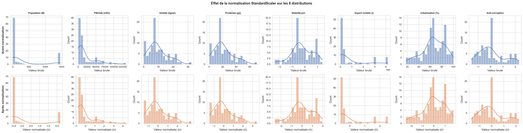

```
Visualisation sauvegardée
```

```python
fig, axes = plt.subplots(2, 8, figsize=(28, 7))

labels = [
    'Population (M)',
    'PIB/hab (USD)',
    'Volaille (kg/an)',
    'Protéines (g/j)',
    'Stabilité pol.',
    'Import volaille (t)',
    'Urbanisation (%)',
    'Anti-corruption'
]

for i, (col, label) in enumerate(zip(variables, labels)):
    sns.histplot(X[col], ax=axes[0, i], kde=True, color='#4C72B0', bins=20)
    axes[0, i].set_title(label, fontsize=9, fontweight='bold')
    axes[0, i].set_xlabel('Valeur brute')

    sns.histplot(X_scaled_df[col], ax=axes[1, i], kde=True, color='#DD8452', bins=20)
    axes[1, i].set_xlabel('Valeur normalisée (σ)')

axes[0, 0].set_ylabel('Avant normalisation', fontsize=11, fontweight='bold')
axes[1, 0].set_ylabel('Après normalisation', fontsize=11, fontweight='bold')

plt.suptitle('Effet de la normalisation StandardScaler sur les 8 distributions',
             fontsize=13, fontweight='bold', y=1.01)
plt.tight_layout()
plt.savefig('outputs/06_normalisation.png', dpi=150, bbox_inches='tight')
plt.show()
print('Visualisation sauvegardée')
```

## 2. Analyse en Composantes Principales (ACP)

L'ACP permet de :

- **Réduire la dimensionnalité** : passer de 8 variables à 2-3 composantes principales
- **Visualiser** les pays dans un espace réduit
- **Identifier** les variables qui expliquent le plus la variance

### 2.1 Calcul de l'ACP et variance expliquée

```python
from sklearn.decomposition import PCA

# ACP sur toutes les composantes pour analyser la variance
pca_full = PCA(n_components=8)
pca_full.fit(X_scaled)

variance_expliquee = pca_full.explained_variance_ratio_
variance_cumulee   = np.cumsum(variance_expliquee)

print('Variance expliquée par composante :')
print(f"  {'Composante':<15} {'Variance':^12} {'Cumulée'}")
print('  ' + '-' * 40)
for i, (v, vc) in enumerate(zip(variance_expliquee, variance_cumulee)):
    print(f'  PC{i+1:<13} {v*100:>6.1f} %       {vc*100:>6.1f} %')
```

```
Variance expliquée par composante :
  Composante        Variance   Cumulée
  ----------------------------------------
  PC1               47.2 %         47.2 %
  PC2               23.3 %         70.5 %
  PC3               18.7 %         89.2 %
  PC4                4.2 %         93.4 %
  PC5                4.0 %         97.5 %
  PC6                1.3 %         98.8 %
  PC7                1.2 %        100.0 %
  PC8                0.0 %        100.0 %
```

### 2.2 Graphique des éboulis (Scree Plot)

Le graphique des éboulis aide à choisir le **nombre optimal de composantes** à retenir. On cherche le "coude" de la courbe, ou le seuil de **70-80% de variance cumulée expliquée**.

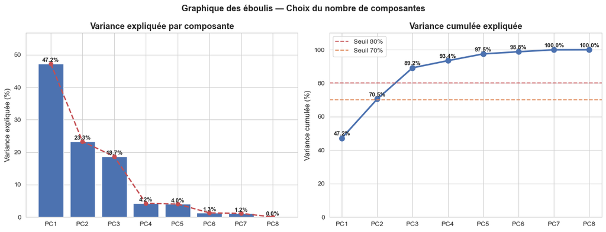

```
→ 3 composantes retenues pour atteindre 80% de variance expliquée
```

```python
fig, axes = plt.subplots(1, 2, figsize=(13, 5))
composantes = [f'PC{i+1}' for i in range(8)]

axes[0].bar(composantes, variance_expliquee * 100, color='#4C72B0', edgecolor='white')
axes[0].plot(composantes, variance_expliquee * 100, 'o--', color='#C44E52', linewidth=2)
for i, v in enumerate(variance_expliquee):
    axes[0].text(i, v * 100 + 0.5, f'{v*100:.1f}%', ha='center', fontsize=9, fontweight='bold')
axes[0].set_title('Variance expliquée par composante', fontweight='bold')
axes[0].set_ylabel('Variance expliquée (%)')
axes[0].set_ylim(0, max(variance_expliquee) * 120)

axes[1].plot(composantes, variance_cumulee * 100, 'o-', color='#4C72B0', linewidth=2.5, markersize=8)
axes[1].axhline(y=80, color='#C44E52', linestyle='--', linewidth=1.5, label='Seuil 80%')
axes[1].axhline(y=70, color='#DD8452', linestyle='--', linewidth=1.5, label='Seuil 70%')
for i, vc in enumerate(variance_cumulee):
    axes[1].text(i, vc * 100 + 1.5, f'{vc*100:.1f}%', ha='center', fontsize=9, fontweight='bold')
axes[1].set_title('Variance cumulée expliquée', fontweight='bold')
axes[1].set_ylabel('Variance cumulée (%)')
axes[1].set_ylim(0, 110)
axes[1].legend()

plt.suptitle('Graphique des éboulis — Choix du nombre de composantes',
             fontsize=13, fontweight='bold')
plt.tight_layout()
plt.savefig('outputs/07_eboulis.png', dpi=150, bbox_inches='tight')
plt.show()

n_comp = int(np.argmax(variance_cumulee >= 0.80)) + 1
print(f'\n→ {n_comp} composantes retenues pour atteindre 80% de variance expliquée')
```

### 2.3 ACP retenue et coordonnées factorielles

```python
# ACP avec le nombre de composantes retenues
pca = PCA(n_components=n_comp)
coordonnees = pca.fit_transform(X_scaled)

# DataFrame des coordonnées factorielles
cols_pca = [f'PC{i+1}' for i in range(n_comp)]
df_pca = pd.DataFrame(coordonnees, columns=cols_pca, index=df.index)
df_pca['pays']   = df['pays'].values
df_pca['region'] = df['region'].values

print(f'ACP retenue : {n_comp} composantes')
print(f'Variance totale expliquée : {pca.explained_variance_ratio_.sum()*100:.1f}%')
df_pca.head(5)
```

```
ACP retenue : 3 composantes
Variance totale expliquée : 89.2%
```

|  | PC1 | PC2 | PC3 | pays | region |
| --- | --- | --- | --- | --- | --- |
| 0 | -1.484045 | -0.926928 | -0.153774 | Algeria | Afrique du Nord |
| 1 | -1.399072 | -0.700228 | -0.144437 | Angola | Afrique subsaharienne |
| 2 | 1.991799 | -0.624523 | 2.283057 | Argentina | Amérique latine |
| 3 | 3.926206 | -0.180349 | 0.154190 | Australia | Océanie |
| 4 | 1.223248 | -0.365920 | -2.001336 | Austria | Europe occidentale |

### 2.4 Cercle des corrélations

Le cercle des corrélations montre comment chaque variable originale se projette sur les deux premières composantes.

- **Flèche longue** : variable bien représentée sur ce plan
- **Flèches proches** : variables corrélées entre elles
- **Flèches opposées** : variables anti-corrélées
- **Flèches perpendiculaires** : variables indépendantes

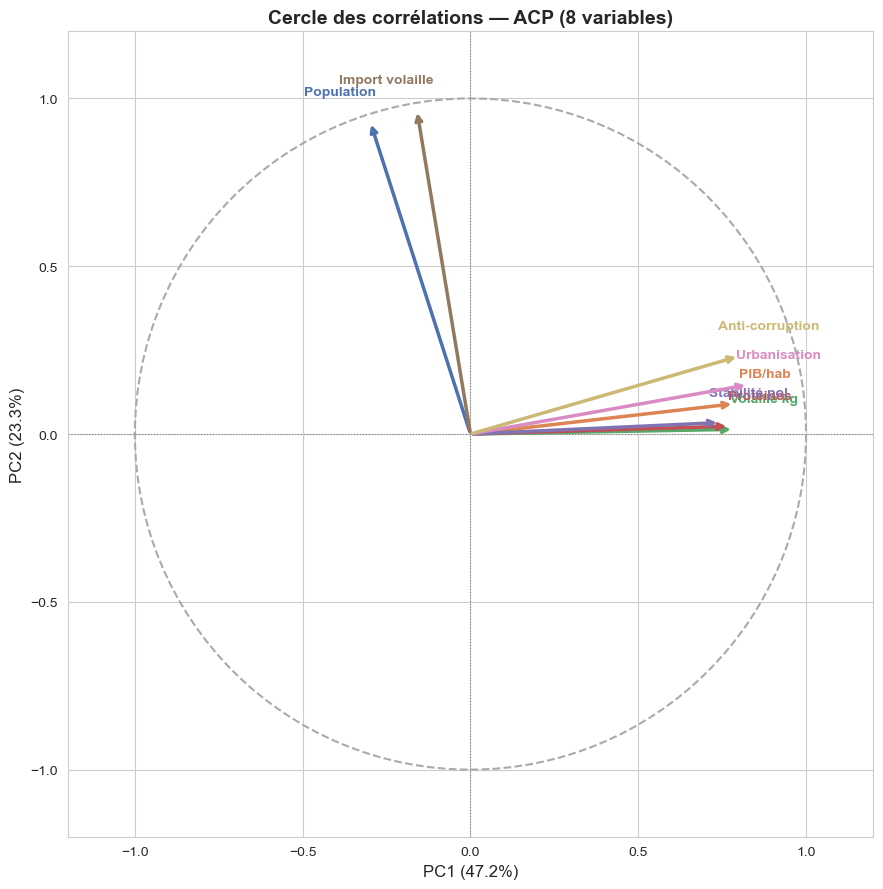

```python
# Corrélations variables → composantes (loadings)
loadings = pca.components_.T * np.sqrt(pca.explained_variance_)

labels_vars = ['Population', 'PIB/hab', 'Volaille kg', 'Protéines',
               'Stabilité pol.', 'Import volaille', 'Urbanisation', 'Anti-corruption']
colors_vars = ['#4C72B0', '#DD8452', '#55A868', '#C44E52',
               '#8172B2', '#937860', '#DA8BC3', '#CCB974']

fig, ax = plt.subplots(figsize=(9, 9))

cercle = plt.Circle((0, 0), 1, color='#AAAAAA', fill=False, linewidth=1.5, linestyle='--')
ax.add_patch(cercle)

for i, (label, color) in enumerate(zip(labels_vars, colors_vars)):
    x, y = loadings[i, 0], loadings[i, 1]
    ax.annotate('', xy=(x, y), xytext=(0, 0),
                arrowprops=dict(arrowstyle='->', color=color, lw=2.5))
    offset = 0.09
    ax.text(x + offset * np.sign(x), y + offset * np.sign(y),
            label, fontsize=10, fontweight='bold', color=color, ha='center', va='center')

ax.axhline(0, color='grey', linewidth=0.8, linestyle=':')
ax.axvline(0, color='grey', linewidth=0.8, linestyle=':')
ax.set_xlim(-1.2, 1.2)
ax.set_ylim(-1.2, 1.2)
ax.set_xlabel(f'PC1 ({pca.explained_variance_ratio_[0]*100:.1f}%)', fontsize=12)
ax.set_ylabel(f'PC2 ({pca.explained_variance_ratio_[1]*100:.1f}%)', fontsize=12)
ax.set_title('Cercle des corrélations — ACP (8 variables)', fontsize=14, fontweight='bold')
ax.set_aspect('equal')
plt.tight_layout()
plt.savefig('outputs/08_cercle_correlations.png', dpi=150, bbox_inches='tight')
plt.show()
```

### 2.5 Projection des pays sur le plan factoriel (PC1 × PC2)

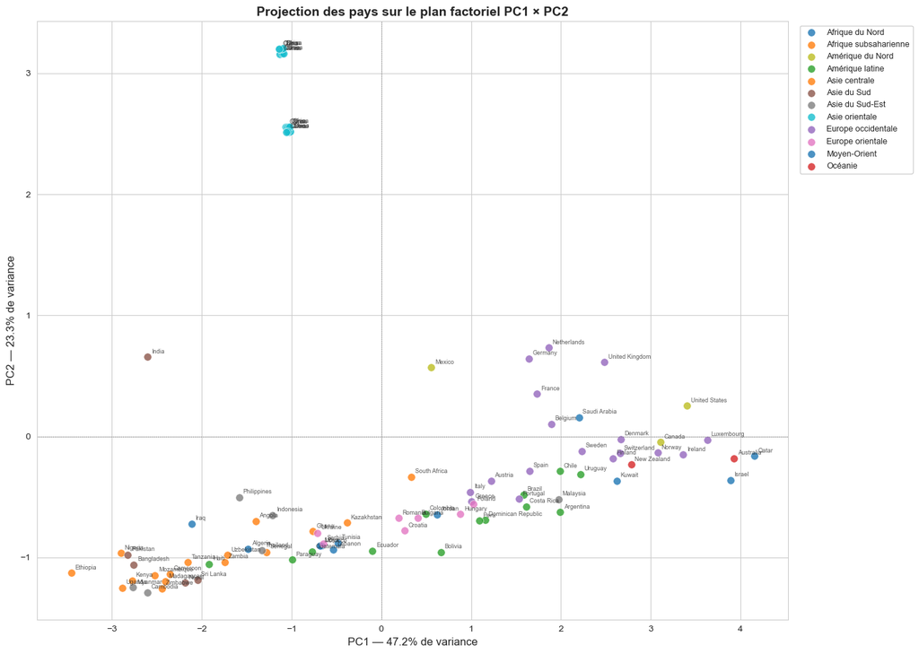

```python
regions_uniques = df_pca['region'].unique()
palette = dict(zip(regions_uniques, sns.color_palette('tab10', len(regions_uniques))))

fig, ax = plt.subplots(figsize=(14, 10))

for region, groupe in df_pca.groupby('region'):
    ax.scatter(groupe['PC1'], groupe['PC2'],
               label=region, color=palette[region],
               s=70, alpha=0.8, edgecolors='white', linewidth=0.5)

for _, row in df_pca.iterrows():
    ax.annotate(row['pays'], (row['PC1'], row['PC2']),
                fontsize=6.5, alpha=0.75,
                xytext=(4, 4), textcoords='offset points')

ax.axhline(0, color='grey', linewidth=0.8, linestyle=':')
ax.axvline(0, color='grey', linewidth=0.8, linestyle=':')
ax.set_xlabel(f'PC1 — {pca.explained_variance_ratio_[0]*100:.1f}% de variance', fontsize=12)
ax.set_ylabel(f'PC2 — {pca.explained_variance_ratio_[1]*100:.1f}% de variance', fontsize=12)
ax.set_title('Projection des pays sur le plan factoriel PC1 × PC2',
             fontsize=14, fontweight='bold')
ax.legend(bbox_to_anchor=(1.01, 1), loc='upper left', fontsize=9, framealpha=0.9)
plt.tight_layout()
plt.savefig('outputs/09_plan_factoriel.png', dpi=150, bbox_inches='tight')
plt.show()
```

### 2.6 Contribution des variables aux composantes

```
Corrélations variables / composantes :
                   PC1    PC2    PC3
Population      -0.299  0.930  0.049
PIB/hab          0.786  0.090 -0.444
Volaille kg      0.785  0.014  0.598
Protéines        0.771  0.023  0.621
Stabilité pol.   0.743  0.034 -0.506
Import volaille -0.160  0.965  0.071
Urbanisation     0.827  0.147  0.242
Anti-corruption  0.800  0.232 -0.497
```

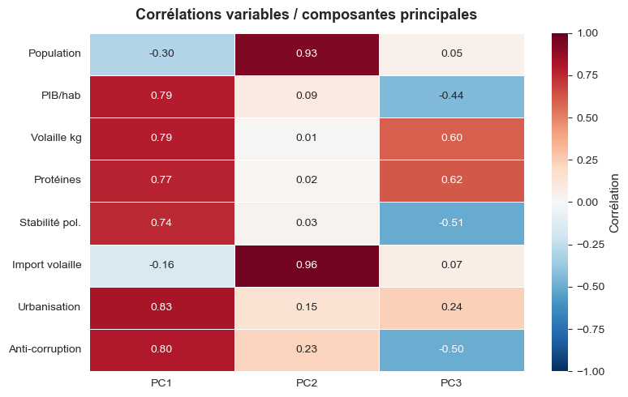

[output not shown]

```python
df_loadings = pd.DataFrame(
    loadings[:, :3],
    index=labels_vars,
    columns=['PC1', 'PC2', 'PC3']
).round(3)

print('Corrélations variables / composantes :')
print(df_loadings.to_string())

fig, ax = plt.subplots(figsize=(8, 5))
sns.heatmap(df_loadings, annot=True, fmt='.2f', cmap='RdBu_r',
            center=0, vmin=-1, vmax=1, ax=ax,
            linewidths=0.5, cbar_kws={'label': 'Corrélation'})
ax.set_title('Corrélations variables / composantes principales',
             fontweight='bold', pad=12)
plt.tight_layout()
plt.savefig('outputs/10_contributions_variables.png', dpi=150, bbox_inches='tight')
plt.show()

print('\nInterprétation attendue :')
print('  PC1 : axe développement — PIB, stabilité, corruption, urbanisation')
print('  PC2 : axe consommation volaille / protéines')
print('  PC3 : axe taille démographique / importations')
```

## 3. Classification Ascendante Hiérarchique (CAH)

La CAH regroupe les pays de façon **ascendante** : elle part de chaque pays seul et fusionne progressivement les groupes les plus proches.

**Avantages :**

- Ne nécessite pas de fixer le nombre de clusters à l'avance
- Le dendrogramme permet de choisir visuellement le bon nombre de groupes

Nous travaillons sur les **coordonnées ACP** (et non sur X_scaled directement) pour bénéficier de la réduction de bruit opérée par l'ACP.

### 3.1 Calcul de la CAH

```python
from scipy.cluster.hierarchy import dendrogram, linkage, fcluster
from scipy.spatial.distance import pdist

# Matrice de liaison — méthode de Ward (minimise la variance intra-cluster)
Z = linkage(coordonnees, method='ward', metric='euclidean')

print(' Matrice de liaison calculée (méthode Ward)')
print(f'   Nombre de pays : {len(coordonnees)}')
print(f'   Nombre de fusions : {len(Z)}')
```

```
 Matrice de liaison calculée (méthode Ward)
   Nombre de pays : 96
   Nombre de fusions : 95
```

### 3.2 Dendrogramme

Le dendrogramme visualise toutes les fusions successives. On choisit le nombre de clusters en **coupant à la hauteur où les fusions sont les plus grandes** (sauts verticaux les plus longs).

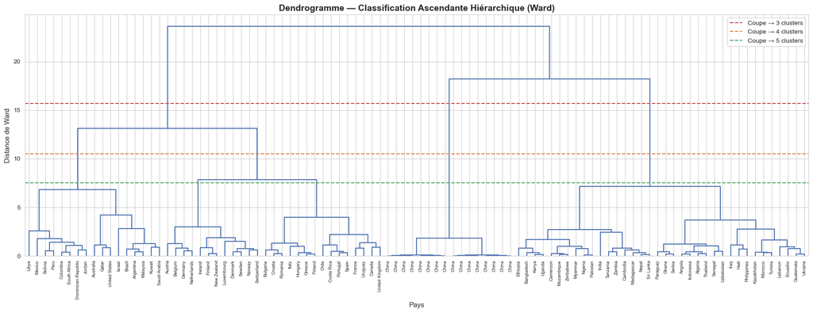

```
Les 8 plus grands sauts de distance (= fusions les plus coûteuses) :
  Fusion 1 : distance = 23.643
  Fusion 2 : distance = 18.227
  Fusion 3 : distance = 13.136
  Fusion 4 : distance = 7.849
  Fusion 5 : distance = 7.159
  Fusion 6 : distance = 6.832
  Fusion 7 : distance = 4.199
  Fusion 8 : distance = 3.962
```

```python
fig, ax = plt.subplots(figsize=(18, 7))

dendrogram(
    Z,
    labels=df['pays'].values,
    leaf_rotation=90,
    leaf_font_size=7,
    color_threshold=0,
    above_threshold_color='#4C72B0',
    ax=ax
)

ax.set_title('Dendrogramme — Classification Ascendante Hiérarchique (Ward)',
             fontsize=14, fontweight='bold')
ax.set_xlabel('Pays', fontsize=11)
ax.set_ylabel('Distance de Ward', fontsize=11)

# Lignes de coupe pour différents nombres de clusters
hauteurs = sorted(Z[:, 2], reverse=True)
for k, color, label in [(3, '#C44E52', '3 clusters'), (4, '#DD8452', '4 clusters'), (5, '#55A868', '5 clusters')]:
    seuil = (hauteurs[k-2] + hauteurs[k-1]) / 2
    ax.axhline(y=seuil, color=color, linestyle='--', linewidth=1.5, label=f'Coupe → {label}')

ax.legend(fontsize=10, loc='upper right')
plt.tight_layout()
plt.savefig('outputs/11_dendrogramme.png', dpi=150, bbox_inches='tight')
plt.show()

# Afficher les 10 plus grands sauts de distance
print('Les 8 plus grands sauts de distance (= fusions les plus coûteuses) :')
for i, h in enumerate(hauteurs[:8]):
    print(f'  Fusion {i+1} : distance = {h:.3f}')
```

### 3.3 Choix du nombre de clusters

On analyse les sauts de distance pour identifier la coupure optimale.

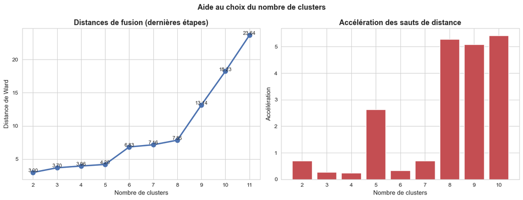

```
→ Nombre de clusters suggéré par le saut maximal : 10
  (Vous pouvez ajuster ce nombre selon votre lecture du dendrogramme)
```

```python
# Visualisation des sauts de distance
n_show = 10  # nombre de dernières fusions à afficher
last_fusions = hauteurs[:n_show]  # distances décroissantes
last_fusions_asc = last_fusions[::-1]  # ordre croissant (k=2 → k=n_show+1)
acceleration = np.diff(last_fusions_asc)  # différences entre hauteurs consécutives

# k_range pour les distances : de 2 à n_show+1 inclus → n_show valeurs
k_range_dist = list(range(2, n_show + 2))           # longueur = n_show
# k_range pour l'accélération : une valeur de moins
k_range_acc  = list(range(2, len(acceleration) + 2)) # longueur = n_show - 1

fig, axes = plt.subplots(1, 2, figsize=(13, 5))

# Gauche : distances de fusion
axes[0].plot(k_range_dist, last_fusions_asc, 'o-', color='#4C72B0', linewidth=2.5, markersize=8)
for k, h in zip(k_range_dist, last_fusions_asc):
    axes[0].text(k, h + 0.05, f'{h:.2f}', ha='center', fontsize=9)
axes[0].set_title('Distances de fusion (dernières étapes)', fontweight='bold')
axes[0].set_xlabel('Nombre de clusters')
axes[0].set_ylabel('Distance de Ward')
axes[0].set_xticks(k_range_dist)

# Droite : accélération des sauts
axes[1].bar(k_range_acc, acceleration, color='#C44E52', edgecolor='white')
axes[1].set_title('Accélération des sauts de distance', fontweight='bold')
axes[1].set_xlabel('Nombre de clusters')
axes[1].set_ylabel('Accélération')
axes[1].set_xticks(k_range_acc)

plt.suptitle('Aide au choix du nombre de clusters', fontsize=13, fontweight='bold')
plt.tight_layout()
plt.savefig('outputs/12_choix_clusters.png', dpi=150, bbox_inches='tight')
plt.show()

k_optimal = int(np.argmax(acceleration)) + 2
print(f'→ Nombre de clusters suggéré par le saut maximal : {k_optimal}')
print('  (Vous pouvez ajuster ce nombre selon votre lecture du dendrogramme)')
```

### 3.4 Affectation des pays aux clusters CAH

```python
# Nombre de clusters retenu (ajuster si nécessaire après lecture du dendrogramme)
n_clusters_cah = k_optimal

# Affectation
labels_cah = fcluster(Z, t=n_clusters_cah, criterion='maxclust')
df['cluster_cah'] = labels_cah
df_pca['cluster_cah'] = labels_cah

print(f'CAH — {n_clusters_cah} clusters :')
print(df['cluster_cah'].value_counts().sort_index().to_string())
print()
print('Répartition par cluster et région :')
print(df.groupby(['cluster_cah', 'region'])['pays'].count().to_string())
```

```
CAH — 10 clusters :
cluster_cah
1      8
2      3
3      6
4     12
5      7
6      8
7     16
8     17
9      9
10    10

Répartition par cluster et région :
cluster_cah  region
1            Afrique du Nord           1
             Afrique subsaharienne     1
             Amérique du Nord          1
             Amérique latine           4
             Moyen-Orient              1
2            Amérique du Nord          1
             Moyen-Orient              1
             Océanie                   1
3            Amérique latine           2
             Asie du Sud-Est           1
             Moyen-Orient              3
4            Europe occidentale       11
             Océanie                   1
5            Europe occidentale        2
             Europe orientale          5
6            Amérique du Nord          1
             Amérique latine           3
             Europe occidentale        4
7            Asie orientale           16
8            Afrique subsaharienne    10
             Asie du Sud               5
             Asie du Sud-Est           2
9            Afrique du Nord           1
             Afrique subsaharienne     3
             Amérique latine           1
             Asie centrale             1
             Asie du Sud-Est           2
             Europe orientale          1
10           Afrique du Nord           2
             Amérique latine           3
             Asie centrale             1
             Asie du Sud-Est           1
             Europe orientale          1
             Moyen-Orient              2
```

### Sur le choix k=4 — Ici je force le nombre de Cluster à 4.

Le graphique suggère k=10 automatiquement mais c'est une erreur classique : l'algorithme détecte le saut maximal dans les grandes distances, ce qui donne trop de clusters trop fins pour une étude de marché. Avec 96 pays et un objectif de recommandation business, k=4 est le bon choix car :

Il est lisible et interprétable Le dendrogramme montre clairement 4 grands groupes Le résultat CAH k=4 est cohérent géographiquement :

Cluster 1 (17 pays) : marchés riches mixtes Cluster 2 (27 pays) : Europe occidentale + orientale dominante Cluster 3 (16 pays) : Asie orientale quasi-exclusive — très homogène Cluster 4 (36 pays) : pays en développement — Afrique, Asie du Sud

### 3.5 Visualisation des clusters CAH sur le plan factoriel

```python
# On force 4 clusters — plus lisible et défendable pour l'étude de marché
n_clusters_cah = 4

# Affectation
labels_cah = fcluster(Z, t=n_clusters_cah, criterion='maxclust')
df['cluster_cah'] = labels_cah
df_pca['cluster_cah'] = labels_cah

print(f'CAH — {n_clusters_cah} clusters :')
print(df['cluster_cah'].value_counts().sort_index().to_string())
print()
print('Répartition par cluster et région :')
print(df.groupby(['cluster_cah', 'region'])['pays'].count().to_string())
```

```
CAH — 4 clusters :
cluster_cah
1    17
2    27
3    16
4    36

Répartition par cluster et région :
cluster_cah  region
1            Afrique du Nord           1
             Afrique subsaharienne     1
             Amérique du Nord          2
             Amérique latine           6
             Asie du Sud-Est           1
             Moyen-Orient              5
             Océanie                   1
2            Amérique du Nord          1
             Amérique latine           3
             Europe occidentale       17
             Europe orientale          5
             Océanie                   1
3            Asie orientale           16
4            Afrique du Nord           3
             Afrique subsaharienne    13
             Amérique latine           4
             Asie centrale             2
             Asie du Sud               5
             Asie du Sud-Est           5
             Europe orientale          2
             Moyen-Orient              2
```

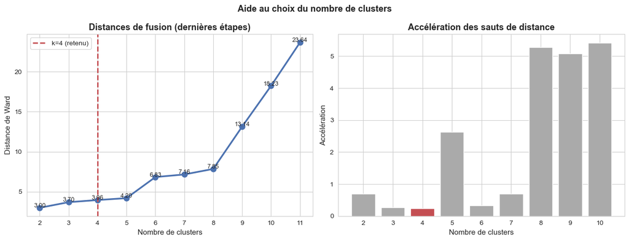

```
→ Nombre de clusters suggéré par le saut maximal : 10
→ Nombre de clusters retenu pour l'étude : 4
  (Choix justifié : 4 profils de marchés distincts et actionnables)
```

```python
# Visualisation des sauts de distance
n_show = 10  # nombre de dernières fusions à afficher
last_fusions = hauteurs[:n_show]
last_fusions_asc = last_fusions[::-1]
acceleration = np.diff(last_fusions_asc)

k_range_dist = list(range(2, n_show + 2))
k_range_acc  = list(range(2, len(acceleration) + 2))

fig, axes = plt.subplots(1, 2, figsize=(13, 5))

# Gauche : distances de fusion — ligne verticale à k=4
axes[0].plot(k_range_dist, last_fusions_asc, 'o-', color='#4C72B0', linewidth=2.5, markersize=8)
for k, h in zip(k_range_dist, last_fusions_asc):
    axes[0].text(k, h + 0.05, f'{h:.2f}', ha='center', fontsize=9)
axes[0].axvline(x=4, color='#C44E52', linestyle='--', linewidth=2, label='k=4 (retenu)')
axes[0].legend(fontsize=10)
axes[0].set_title('Distances de fusion (dernières étapes)', fontweight='bold')
axes[0].set_xlabel('Nombre de clusters')
axes[0].set_ylabel('Distance de Ward')
axes[0].set_xticks(k_range_dist)

# Droite : accélération — barre k=4 mise en évidence
couleurs_acc = ['#C44E52' if k == 4 else '#AAAAAA' for k in k_range_acc]
axes[1].bar(k_range_acc, acceleration, color=couleurs_acc, edgecolor='white')
axes[1].set_title('Accélération des sauts de distance', fontweight='bold')
axes[1].set_xlabel('Nombre de clusters')
axes[1].set_ylabel('Accélération')
axes[1].set_xticks(k_range_acc)

plt.suptitle('Aide au choix du nombre de clusters', fontsize=13, fontweight='bold')
plt.tight_layout()
plt.savefig('outputs/12_choix_clusters.png', dpi=150, bbox_inches='tight')
plt.show()

k_optimal = int(np.argmax(acceleration)) + 2
print(f'→ Nombre de clusters suggéré par le saut maximal : {k_optimal}')
print(f'→ Nombre de clusters retenu pour l\'étude : 4')
print('  (Choix justifié : 4 profils de marchés distincts et actionnables)')
```

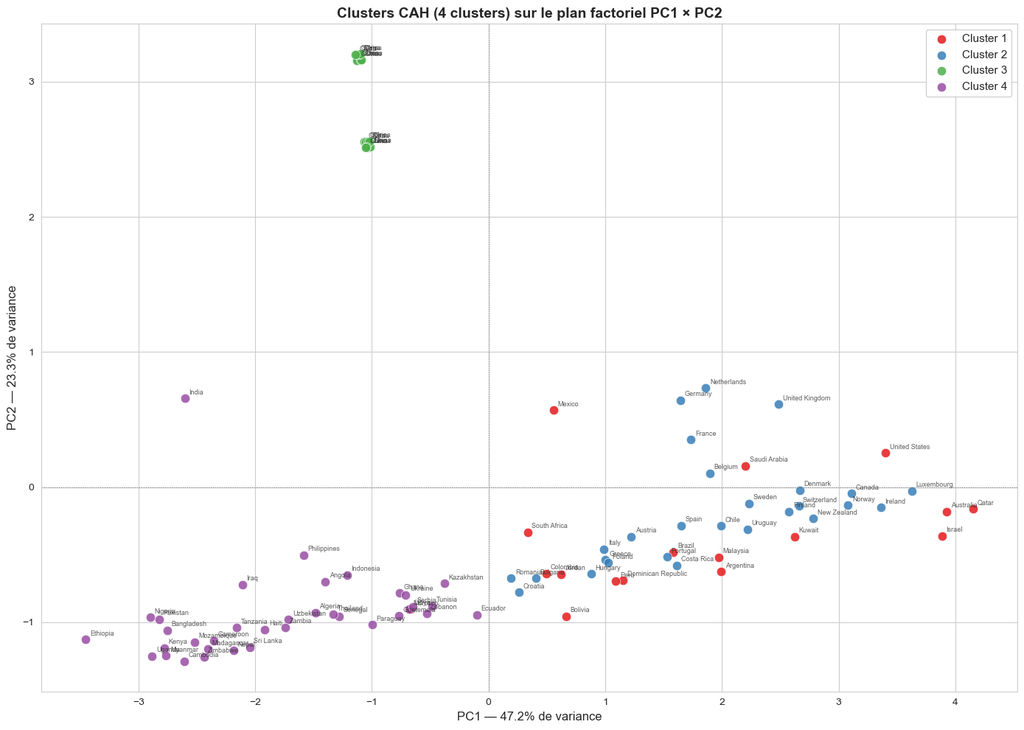

```python
# Si n_clusters_cah n'est pas défini, décommentez la ligne suivante et choisissez votre valeur :
# n_clusters_cah = 4  # Le choix a été fait en fonction de ma lecture du dendrogramme

palette_clusters = sns.color_palette('Set1', n_clusters_cah)

fig, ax = plt.subplots(figsize=(14, 10))

for cluster_id in sorted(df_pca['cluster_cah'].unique()):
    mask = df_pca['cluster_cah'] == cluster_id
    ax.scatter(
        df_pca.loc[mask, 'PC1'],
        df_pca.loc[mask, 'PC2'],
        label=f'Cluster {cluster_id}',
        color=palette_clusters[cluster_id - 1],
        s=80, alpha=0.85, edgecolors='white', linewidth=0.5
    )

for _, row in df_pca.iterrows():
    ax.annotate(row['pays'], (row['PC1'], row['PC2']),
                fontsize=6.5, alpha=0.75,
                xytext=(4, 4), textcoords='offset points')

ax.axhline(0, color='grey', linewidth=0.8, linestyle=':')
ax.axvline(0, color='grey', linewidth=0.8, linestyle=':')
ax.set_xlabel(f'PC1 — {pca.explained_variance_ratio_[0]*100:.1f}% de variance', fontsize=12)
ax.set_ylabel(f'PC2 — {pca.explained_variance_ratio_[1]*100:.1f}% de variance', fontsize=12)
ax.set_title(f'Clusters CAH ({n_clusters_cah} clusters) sur le plan factoriel PC1 × PC2',
             fontsize=14, fontweight='bold')
ax.legend(fontsize=11, framealpha=0.9)
plt.tight_layout()
plt.savefig('outputs/13_clusters_cah_plan_factoriel.png', dpi=150, bbox_inches='tight')
plt.show()
```

### 3.6 Profils moyens des clusters CAH

```
Profils moyens par cluster CAH :
             population_M  pib_hab_usd  volaille_kg_hab  proteines_g  stabilite_politique  import_volaille_t  taux_urbanisation  controle_corruption
cluster_cah
1                   59.85     23454.26            20.32        44.82                -0.32          390762.47              84.67                -0.02
2                   21.30     46706.29            11.26        24.13                 0.76          399652.03              78.03                 1.27
3                 1442.31     12492.98             7.70        17.31                -0.52         3565387.04              62.85                 0.04
4                   94.92      3162.12             4.58        10.11                -0.81          107129.68              49.21                -0.73
```

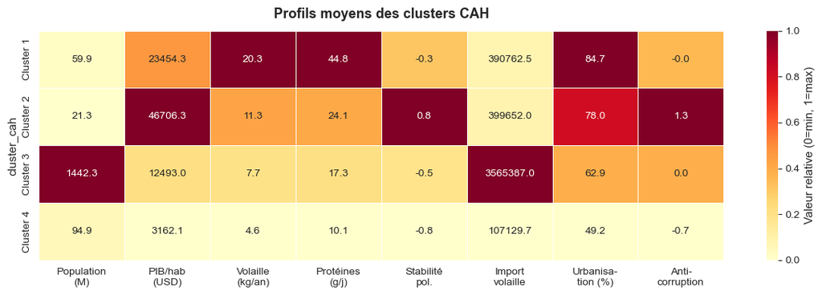

```python
profils = df.groupby('cluster_cah')[variables].mean().round(2)
print('Profils moyens par cluster CAH :')
print(profils.to_string())

profils_norm = (profils - profils.min()) / (profils.max() - profils.min())

xlabels = ['Population\n(M)', 'PIB/hab\n(USD)', 'Volaille\n(kg/an)', 'Protéines\n(g/j)',
           'Stabilité\npol.', 'Import\nvolaille', 'Urbanisa-\ntion (%)', 'Anti-\ncorruption']

fig, ax = plt.subplots(figsize=(12, 4))
sns.heatmap(
    profils_norm,
    annot=profils.values, fmt='.1f',
    cmap='YlOrRd', ax=ax,
    linewidths=0.5,
    xticklabels=xlabels,
    yticklabels=[f'Cluster {i}' for i in profils.index],
    cbar_kws={'label': 'Valeur relative (0=min, 1=max)'}
)
ax.set_title('Profils moyens des clusters CAH', fontsize=13, fontweight='bold', pad=12)
plt.tight_layout()
plt.savefig('outputs/14_profils_clusters_cah.png', dpi=150, bbox_inches='tight')
plt.show()
```

## 4. K-means

Le K-means confirme et affine les clusters identifiés par la CAH.

**Différence avec la CAH :**

- La CAH est **déterministe** mais sensible aux outliers
- Le K-means **optimise itérativement** les centroïdes — plus robuste sur grands datasets

Nous initialisons le K-means avec **k=4** (résultat de la CAH) et vérifions la stabilité des groupes.

### 4.1 Méthode du coude (confirmation de k=4)

[output not shown]

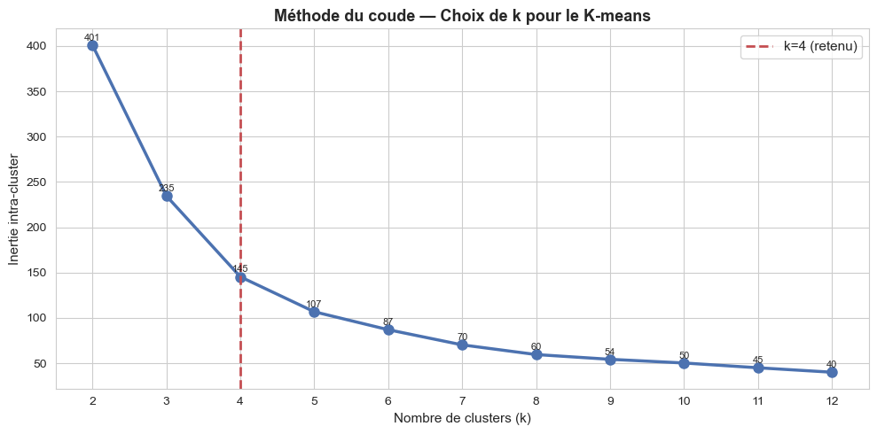

```python
from sklearn.cluster import KMeans

# Inertie pour k de 2 à 12
inerties = []
k_values = range(2, 13)

for k in k_values:
    km = KMeans(n_clusters=k, init='k-means++', n_init=20, random_state=42)
    km.fit(coordonnees)
    inerties.append(km.inertia_)

fig, ax = plt.subplots(figsize=(10, 5))
ax.plot(list(k_values), inerties, 'o-', color='#4C72B0', linewidth=2.5, markersize=8)
ax.axvline(x=4, color='#C44E52', linestyle='--', linewidth=2, label='k=4 (retenu)')
for k, inertie in zip(k_values, inerties):
    ax.text(k, inertie + 5, f'{inertie:.0f}', ha='center', fontsize=8)
ax.set_title('Méthode du coude — Choix de k pour le K-means', fontweight='bold')
ax.set_xlabel('Nombre de clusters (k)')
ax.set_ylabel('Inertie intra-cluster')
ax.set_xticks(list(k_values))
ax.legend(fontsize=11)
plt.tight_layout()
plt.savefig('outputs/15_kmeans_coude.png', dpi=150, bbox_inches='tight')
plt.show()
```

### 4.2 Ajustement du K-means avec k=4

```python
# K-means final
kmeans = KMeans(n_clusters=4, init='k-means++', n_init=50, random_state=42)
labels_km = kmeans.fit_predict(coordonnees)

df['cluster_km'] = labels_km + 1  # +1 pour commencer à 1
df_pca['cluster_km'] = labels_km + 1

print('K-means — 4 clusters :')
print(df['cluster_km'].value_counts().sort_index().to_string())
print()

# Comparaison CAH vs K-means
from sklearn.metrics import adjusted_rand_score
ari = adjusted_rand_score(df['cluster_cah'], df['cluster_km'])
print(f'Adjusted Rand Index (CAH vs K-means) : {ari:.3f}')
print('(1.0 = clusters identiques, 0 = aléatoire)')
```

```
K-means — 4 clusters :
cluster_km
1    36
2    25
3    16
4    19

Adjusted Rand Index (CAH vs K-means) : 0.719
(1.0 = clusters identiques, 0 = aléatoire)
```

### 4.3 Clusters K-means sur le plan factoriel

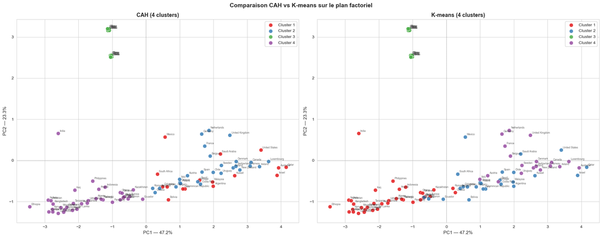

```python
palette_km = sns.color_palette('Set1', 4)

fig, axes = plt.subplots(1, 2, figsize=(20, 8))

for idx, (col_cluster, titre) in enumerate([
    ('cluster_cah', 'CAH (4 clusters)'),
    ('cluster_km',  'K-means (4 clusters)')
]):
    ax = axes[idx]
    for cluster_id in sorted(df_pca[col_cluster].unique()):
        mask = df_pca[col_cluster] == cluster_id
        ax.scatter(
            df_pca.loc[mask, 'PC1'],
            df_pca.loc[mask, 'PC2'],
            label=f'Cluster {cluster_id}',
            color=palette_km[cluster_id - 1],
            s=80, alpha=0.85, edgecolors='white', linewidth=0.5
        )
    for _, row in df_pca.iterrows():
        ax.annotate(row['pays'], (row['PC1'], row['PC2']),
                    fontsize=6, alpha=0.7,
                    xytext=(4, 4), textcoords='offset points')
    ax.axhline(0, color='grey', linewidth=0.8, linestyle=':')
    ax.axvline(0, color='grey', linewidth=0.8, linestyle=':')
    ax.set_xlabel(f'PC1 — {pca.explained_variance_ratio_[0]*100:.1f}%', fontsize=11)
    ax.set_ylabel(f'PC2 — {pca.explained_variance_ratio_[1]*100:.1f}%', fontsize=11)
    ax.set_title(titre, fontsize=13, fontweight='bold')
    ax.legend(fontsize=10, framealpha=0.9)

plt.suptitle('Comparaison CAH vs K-means sur le plan factoriel',
             fontsize=14, fontweight='bold')
plt.tight_layout()
plt.savefig('outputs/16_comparaison_cah_kmeans.png', dpi=150, bbox_inches='tight')
plt.show()
```

### 4.4 Profils moyens des clusters K-means

On nomme chaque cluster selon son profil pour l'interprétation finale.

```
Profils moyens K-means :
            population_M  pib_hab_usd  volaille_kg_hab  proteines_g  stabilite_politique  import_volaille_t  taux_urbanisation  controle_corruption
cluster_km
1                  94.91      3776.28             4.47         9.85                -0.72          116503.56              48.05                -0.68
2                  46.09     18849.99            17.57        38.73                -0.19          326359.39              81.86                -0.02
3                1442.31     12492.98             7.70        17.31                -0.52         3565387.04              62.85                 0.04
4                  23.18     61391.19            11.27        23.94                 0.89          470374.88              81.15                 1.71
```

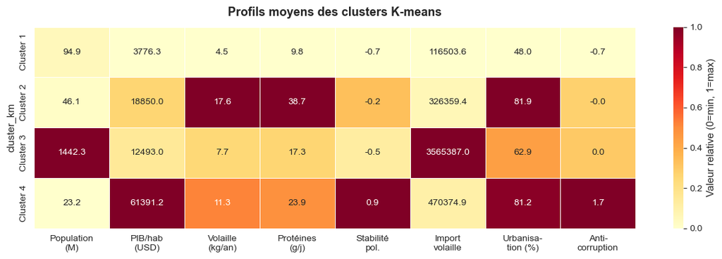

```python
profils_km = df.groupby('cluster_km')[variables].mean().round(2)
print('Profils moyens K-means :')
print(profils_km.to_string())

profils_km_norm = (profils_km - profils_km.min()) / (profils_km.max() - profils_km.min())

xlabels = ['Population\n(M)', 'PIB/hab\n(USD)', 'Volaille\n(kg/an)', 'Protéines\n(g/j)',
           'Stabilité\npol.', 'Import\nvolaille', 'Urbanisa-\ntion (%)', 'Anti-\ncorruption']

fig, ax = plt.subplots(figsize=(12, 4))
sns.heatmap(
    profils_km_norm,
    annot=profils_km.values, fmt='.1f',
    cmap='YlOrRd', ax=ax,
    linewidths=0.5,
    xticklabels=xlabels,
    yticklabels=[f'Cluster {i}' for i in profils_km.index],
    cbar_kws={'label': 'Valeur relative (0=min, 1=max)'}
)
ax.set_title('Profils moyens des clusters K-means', fontsize=13, fontweight='bold', pad=12)
plt.tight_layout()
plt.savefig('outputs/17_profils_kmeans.png', dpi=150, bbox_inches='tight')
plt.show()
```

### 4.5 Matrice de confusion CAH vs K-means

Permet de voir quels pays ont changé de cluster entre les deux méthodes.

```
Matrice de confusion CAH vs K-means :
K-means   1   2   3   4
CAH
1         0  16   0   1
2         2   7   0  18
3         0   0  16   0
4        34   2   0   0
```

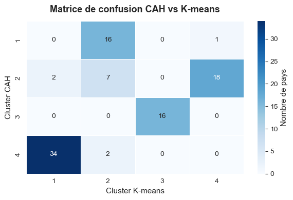

```
Pays avec affectation différente entre CAH et K-means : 73
              pays                region  cluster_cah  cluster_km
           Algeria       Afrique du Nord            4           1
            Angola Afrique subsaharienne            4           1
         Argentina       Amérique latine            1           2
         Australia               Océanie            1           4
           Austria    Europe occidentale            2           4
        Bangladesh           Asie du Sud            4           1
           Belgium    Europe occidentale            2           4
           Bolivia       Amérique latine            1           2
            Brazil       Amérique latine            1           2
          Cambodia       Asie du Sud-Est            4           1
          Cameroon Afrique subsaharienne            4           1
            Canada      Amérique du Nord            2           4
          Colombia       Amérique latine            1           2
           Croatia      Europe orientale            2           1
           Denmark    Europe occidentale            2           4
Dominican Republic       Amérique latine            1           2
           Ecuador       Amérique latine            4           2
          Ethiopia Afrique subsaharienne            4           1
           Finland    Europe occidentale            2           4
            France    Europe occidentale            2           4
           Germany    Europe occidentale            2           4
             Ghana Afrique subsaharienne            4           1
         Guatemala       Amérique latine            4           1
             Haiti       Amérique latine            4           1
             India           Asie du Sud            4           1
         Indonesia       Asie du Sud-Est            4           1
              Iraq          Moyen-Orient            4           1
           Ireland    Europe occidentale            2           4
            Israel          Moyen-Orient            1           2
             Italy    Europe occidentale            2           4
            Jordan          Moyen-Orient            1           2
        Kazakhstan         Asie centrale            4           1
             Kenya Afrique subsaharienne            4           1
            Kuwait          Moyen-Orient            1           2
           Lebanon          Moyen-Orient            4           2
             Libya       Afrique du Nord            1           2
        Luxembourg    Europe occidentale            2           4
        Madagascar Afrique subsaharienne            4           1
```

[output cut: 20 more lines]

```
      South Africa Afrique subsaharienne            1           2
         Sri Lanka           Asie du Sud            4           1
            Sweden    Europe occidentale            2           4
       Switzerland    Europe occidentale            2           4
          Tanzania Afrique subsaharienne            4           1
          Thailand       Asie du Sud-Est            4           1
           Tunisia       Afrique du Nord            4           1
            Uganda Afrique subsaharienne            4           1
           Ukraine      Europe orientale            4           1
    United Kingdom    Europe occidentale            2           4
     United States      Amérique du Nord            1           2
           Uruguay       Amérique latine            2           4
        Uzbekistan         Asie centrale            4           1
            Zambia Afrique subsaharienne            4           1
          Zimbabwe Afrique subsaharienne            4           1
```

```python
confusion = pd.crosstab(
    df['cluster_cah'], df['cluster_km'],
    rownames=['CAH'], colnames=['K-means']
)
print('Matrice de confusion CAH vs K-means :')
print(confusion.to_string())

fig, ax = plt.subplots(figsize=(6, 4))
sns.heatmap(confusion, annot=True, fmt='d', cmap='Blues', ax=ax,
            linewidths=0.5, cbar_kws={'label': 'Nombre de pays'})
ax.set_title('Matrice de confusion CAH vs K-means', fontweight='bold', pad=12)
ax.set_xlabel('Cluster K-means')
ax.set_ylabel('Cluster CAH')
plt.tight_layout()
plt.savefig('outputs/18_matrice_confusion_cah_kmeans.png', dpi=150, bbox_inches='tight')
plt.show()

# Pays qui ont changé de cluster
df['cluster_final'] = df['cluster_km']  # on retient le K-means comme référence finale
diff = df[df['cluster_cah'] != df['cluster_km']][['pays', 'region', 'cluster_cah', 'cluster_km']]
print(f'\nPays avec affectation différente entre CAH et K-means : {len(diff)}')
if len(diff) > 0:
    print(diff.to_string(index=False))
```